Oct 29, 2026

## Turn open ends into insight: Coding Open Ends in Crunch

Open-ended questions often tell you the most, but coding them by hand is slow. Now, you can turn open text variables into categories in a few clicks, without leaving Crunch.

## Benefits

- Faster coding: Crunch uses AI to find the main themes in your responses and assign each response to a category, so the work takes minutes, not days.
- Consistent results: Save your categories as a taxonomy and reuse it on the same dataset or a different one. That keeps waves, markets, and studies comparable.
- You stay in control: Review, rename, merge, or adjust categories before you use them in your analysis.

## How does it work?

Open a dataset and find the open text variable you want to code. Select Categorize responses from the variable menu.

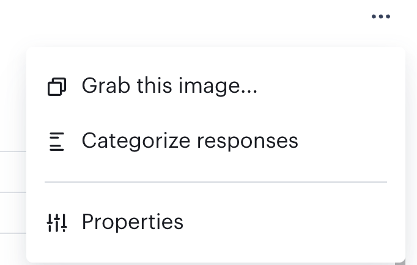

Choose to generate new categories or apply an existing taxonomy. If you generate new ones Crunch generates suggested themes and codes each response. If you use an existing taxonomy, responses are coded into the categories you’ve already defined.

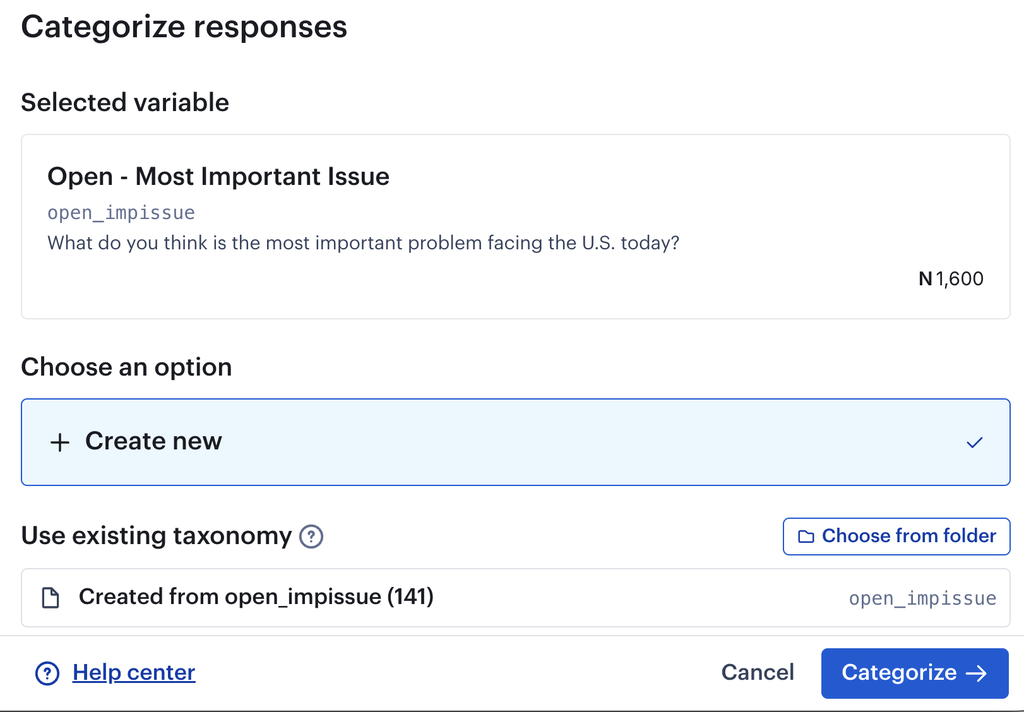

Review the results, refine the categories as needed, and save. The coded variable is then ready to use in tables, charts and filters like any other categorical variable.

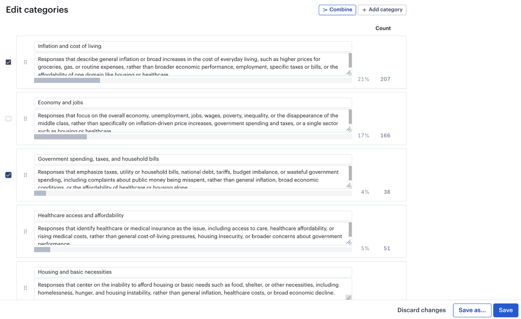

## Try it out today

Coding Open Ends is now in [early access](https://help.crunch.io/hc/en-us/articles/360040465331-How-to-enable-early-access) for Editors. For full details of this new feature, see the [help center](https://help.crunch.io/hc/en-us/articles/49912670961677-Categorizing-Open-Ends).

## Your feedback matters

As always, we’re constantly evolving our products to make your job easier, and eager to hear what you think about our latest enhancements. For questions or feedback, please contact support@crunch.io.